# tmp0b2wfg65

## 思想剧场：哲学探险家毕业典礼

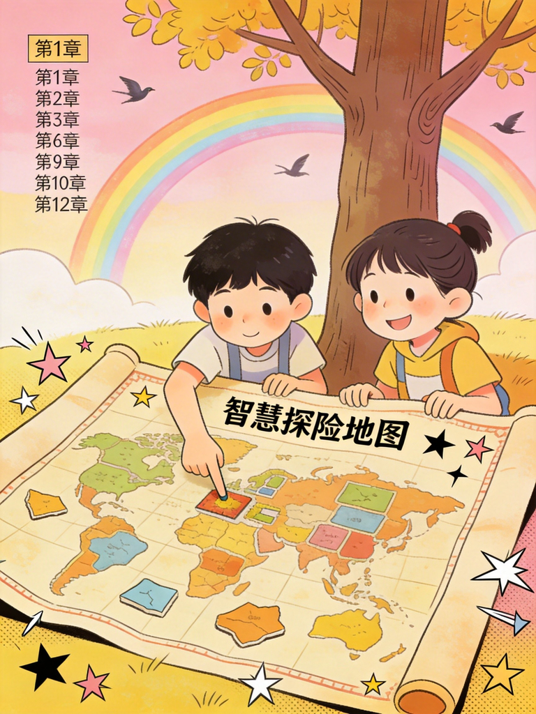

## 第一课时：梁启超——哲学改变命运的真实案例

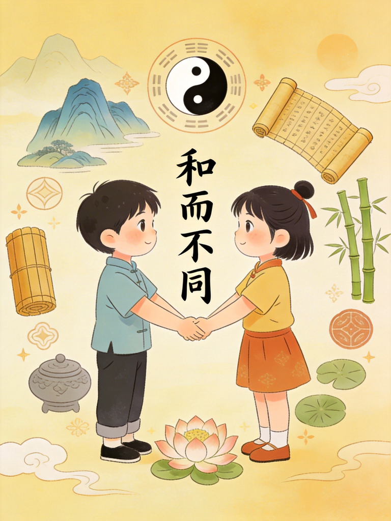

## 第二课时：冯友兰——哲学让你看懂世界

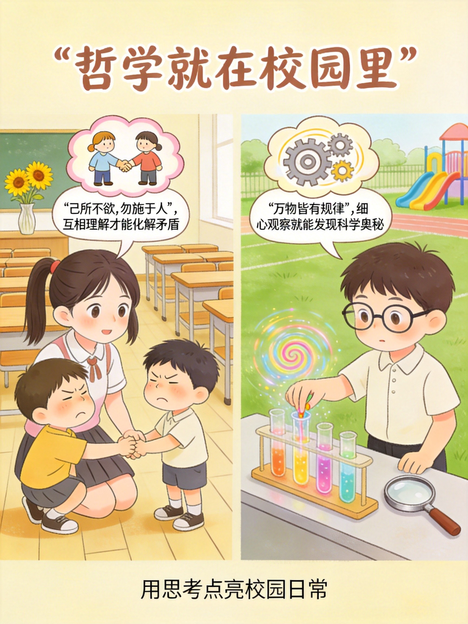

# 第十二章：我们为什么要学哲学？——探险家的毕业典礼与终身邀请

**时间**：初夏午后  
**地点**：校园小花园，12张长椅围成半圆  
**人物**：哲学俱乐部全体成员（小智、小慧、小美、小强等12人），以及从书中走出的三位特别嘉宾

**场景**： 12个孩子每人手里拿着一个精致的木盒，里面装着12个月来收集的“智慧探险地图碎片”。今天，他们要完成最后一块碎片的拼图，举办一场特别的“哲学探险家毕业典礼”。

**小智**：（打开木盒）从“世界从哪里来”到“如何当现代中国人”，12个大问题，12位哲人朋友…我好像走了2500年。

**小慧**：但奇怪的是，我的问题不仅没减少，反而变多了。原来我以为哲学是“找答案”，现在发现是“学会问更好的问题”。

**小美**：这就是哲学最神奇的地方——它不给你终点，只给你一双更敏锐的眼睛。

**突然，花园入口处传来三个声音——** **梁启超**（1873-1929，穿中山装，目光炯炯）：孩子们，听说你们要“毕业”？在哲学里，毕业只是另一个开始。 **冯友兰**（1895-1990，戴眼镜，儒雅温和）：我花了半辈子把中国哲学翻译给世界看，现在轮到你们把哲学“翻译”进自己的生活了。 **熊十力**（1885-1968，长衫飘飘，手拿烟斗）：毕业？哲学是终身的健身房，你们才刚做完热身运动呢！ **小强**：（惊讶）三位先生，你们…都是近代的思想家？为什么一起来参加我们的毕业典礼？

**梁启超**：因为我们三个，正好代表了“为什么学哲学”的三个核心理由——改变社会、理解世界、修炼生命。而你们这12个月的探险，已经不知不觉踏上了这三条路。

**小慧**：（举手提问）梁先生，您说“改变社会”——哲学真的能改变社会吗？我觉得哲学好像都是在书斋里思考…

**梁启超**：（微笑）好问题！这是我今天的第一个🌟

**新民**任务——告诉你哲学如何从书斋走向街头。但首先，让我们正式开启这场“毕业对话”。 — ### 思想剧场：从“考试机器”到“新民运动家”

**梁启超**：我18岁时，是广东最会考试的学生之一。八股文、经典背诵，我样样精通。但我问自己：我读书是为了什么？

**小智**：为了…考科举，当官？

**梁启超**：对，当时所有人都这么想。直到我遇到康有为老师，他问我：“梁启超，你读这些经典，是为了在试卷上得高分，还是为了

**改变四万万同胞的命运**？” **小美**：（震惊）这个问题…好重。

**梁启超**：是的，这个问题像一记重锤，敲醒了我的“考试梦”。我突然明白：

**哲学不是知识装饰品，是改变现实的武器**。 **小强**：（质疑）但是梁先生，我们现在学的哲学概念，比如“仁”“道”“逍遥”，这些怎么变成“武器”呢？

**梁启超**：又一个好问题！这就是我要教的——

**哲学工具的应用转换**。 —

#### 古人这么做：《新民说》的实践密码 **梁启超**：我写《新民说》，不是为了让学者写论文，而是为了让每个普通人都能： 1.

**用“仁”解决冲突**  
- 同学吵架时，不想“谁赢谁输”，想“如果我是对方，希望被怎样对待？”  
- 这就是🌟**仁**（心里那个“不想让别人难过”的开关）从概念到行动的转化。 2. **用“天下兴亡匹夫有责”激活公民意识**  
- 看到校园里有浪费水电，不觉得“不关我事”，主动关掉并提醒同学。  
- 这就是🌟**天下兴亡匹夫有责**（班级大扫除，每个人都有自己的“责任区”）的日常实践。 3. **用“经世致用”检验学习效果**  
- 学了数学比例，不只在试卷上做题，动手设计一个小型节水装置模型。  
- 这就是🌟**经世致用**（把乐高说明书变成真实模型）的创造力释放。 **小慧**：（兴奋）我懂了！上周我们班选举班委，有两个候选人差点吵起来。我那时候就想到了孟子的“恻隐之心”，然后站起来说：“我们不是要选谁赢，是要选谁最能服务班级。”后来他们握手言和了！

**社会视角**：“如果每个人都像我这样想/做，世界会变得更好还是更糟？” 3.

**新民行动**：“今天我的一小步‘新民’行动是什么？（哪怕只是对陌生人微笑）”

**小美**：（记录）第一个问题让我想起王阳明的🌟

**知行合一**（知道火烫手就不摸）——真知道就要真行动。 **小强**：（质疑反驳）但是梁先生，有时候我觉得个人力量太小了。比如环保问题，我一个人节约用水，能改变全球变暖吗？

**梁启超**：这个问题问到了关键！我的回答是：

**哲学改变的不是“结果”，而是“因果链条”**。 - 你节约用水 → 影响同桌 → 同桌影响家人 → 家人影响社区…  
- **哲学思维是涟漪的起点**，它改变的不是单次行动的结果，而是行动背后的思维模式，以及这种模式在人际关系中的传播。 **小智**：（立场选择）所以，我应该更关注“我是否在用哲学思维生活”，而不是“我的行动能否立即改变世界”？

**梁启超**：完全正确！这是你今天第一个立场选择——

**从“结果焦虑”转向“过程确信”**。 — ### 实践卡片：我的“新民行动日志” **任务**：连续记录一周，每天完成一次“新民行动”： | 日期 | 哲学概念使用 | 行动内容 | 影响范围 | 我的感受 | |——|————-|———-|———-|———-| | 周一 | 🌟仁 | 帮助忘了带饭卡的同学打饭 | 1人 | 温暖+1 | | 周二 | 🌟天下为公 | 整理共享图书角 | 全班 | 责任感+1 | | … | … | … | … | … |

**进阶挑战**：设计一个“班级新民计划”，用哲学思维解决一个班级实际问题（如：如何减少同学间的语言暴力？）。 — ### 思想剧场：给外国朋友的“道”翻译

**冯友兰**：（温和地）孩子们，梁先生讲的是“用哲学”，我现在要讲的是“懂哲学”——特别是如何

**跨文化地懂**。 **场景闪回**：1940年代，美国哥伦比亚大学办公室。

**美国学生John**：Dr. Feng，你们中国人总说“道”，到底是什么？是God吗？

**冯友兰**：（摇头微笑）不是。“道”是

**process，不是person**。就像水往低处流——不是水“想”流，是重力这个“道”让它流。 **John**：So it’s like “Nature”？

**冯友兰**：类似，但有

**moral dimension**。“道”既是“what is”（现实），又是“what should be”（理想）——现实和理想在“道”里是统一的。 **小慧**：（对同学们）冯先生这是在做什么？

**小美**：他在做🌟

**跨文化翻译**——把中国哲学的独特概念，用西方人能懂的语言解释。 —

#### 古人这么做：《中国哲学简史》的翻译智慧 **冯友兰**：我写《中国哲学简史》，核心方法是🌟

**释古**——不是“考古”，而是“**同情理解+创造性诠释**”。 **释古三步法**： 1.

**找到“问题意识”**  
- 问：古人为什么思考这个问题？他的时代遇到了什么困境？  
- 例：孔子说“仁”，是因为春秋时代礼崩乐坏，人际关系破碎。 2. **提取“核心关怀”**  
- 问：这个概念背后，是对什么价值的追求？  
- 例：“仁”的核心是**把人当人看**，恢复人与人的温暖联系。 3. **建立“跨文化对话”**  
- 问：同样的价值追求，在其他文化中如何表达？  
- 例：基督教的“爱你的邻人”、佛教的“慈悲”，都是“仁”的亲戚。 **小强**：（提问）冯先生，您这样“翻译”，会不会歪曲古人的原意？

**冯友兰**：又一个深刻的问题！我的回答是：

**理解不是复印，是对话**。 - 复印：100%重复原文，但可能谁都看不懂  
- 对话：抓住精神实质，用当代语言重新表达  
- **好的翻译是让死去的思想在新时代复活** **小智**：（质疑反驳）但是每个人都可以有自己的“翻译”，那不就乱了吗？比如有人说“道”是上帝，有人说“道”是自然规律…

**冯友兰**：这正是哲学的魅力所在！

**哲学不是标准答案库，是理性对话的场域**。你可以在不同翻译间比较、辩论、选择——这个过程本身就是哲学训练。 — #### 全球望远镜：1940s的东西方哲学共振

**冯友兰**：我在美国讲“道”的时候，欧洲的哲学家们也在问类似的问题。 | 对比维度 | 中国哲学（冯友兰诠释） | 西方存在主义（萨特、加缪） | |———-|———————-|————————–| |

**核心问题** | 如何在天人合一中找到意义？ | 个体在荒谬世界中如何创造意义？ | | **起点** | 关系中的和谐 | 个体的孤独焦虑 | | **方法** | 修身→齐家→治国→平天下 | 自由选择→承担责任 | | **终极目标** | 与道合一 | 成为真实的自己 | **对比点**：东方哲学从“关系和谐”寻找意义，西方哲学从“个体自由”创造意义。

**差异说明（儿童比喻）**： - 东方哲学像

**编织毛衣**：每一针都连接着其他线，意义在于整体的温暖与和谐。 - 西方哲学像

**搭积木**：每一块都是独立的选择，意义在于你创造出的独特建筑。 【视觉建议】简笔画地图：左边画中国地图，上面有“关系网”图案；右边画欧洲地图，上面有“个体小人”图案；中间用桥梁连接，桥梁上写着“对话”。

**小美**：（思考）所以，东方哲学从“关系”出发，西方哲学从“个体”出发，但最后都指向“如何活得有意义”？

**冯友兰**：正是！这就是🌟

**哲学普遍性**——不同文化用不同语言，讨论同样的人类根本关切。 **思考题**： 1. 如果你是一位生活在1940年代的中国青年，面临战争与民族危机，你会更倾向哪种哲学思维？为什么？ 2. 如果你是一位同时期的欧洲青年，经历二战创伤，又会如何选择？ 3. 想象这两种思维进行对话：东方的“关系和谐”与西方的“个体自由”，它们可能互相学到什么？

**小慧**：（立场选择）那我学哲学时，应该更关注“找到唯一正确答案”，还是“理解不同思考角度”？

**冯友兰**：这是你今天第二个立场选择。我的建议是：

**先理解多样性，再形成自己的判断**。哲学不是快餐，是慢炖——需要时间消化不同观点。 —

### 实践卡片：我的“哲学翻译官”练习 **任务**：选一个中国哲学概念，为三种不同背景的人做“翻译”： 1.

**给小学生弟弟/妹妹**  
- 概念：🌟**无为**  
- 翻译：“就像种花，你不能每天把花拔出来看根长了没有——要相信花会自己长大。” 2. **给外国网友（用英语思维）**  
- 概念：🌟**心即理**  
- 翻译：“Your heart already knows what’s right—no need to search outside for moral rules.” 3. **给未来的自己（10年后）**  
- 概念：🌟**逍遥游**  
- 翻译：“无论多忙，记得给心灵留一片自由飞翔的天空。” **进阶挑战**：组织一次“哲学概念翻译大赛”，看谁能用最生动的比喻解释抽象概念。 — ## 第三课时：熊十力——哲学是生命的修炼 ### 思想剧场：把哲学当“健身房”

**熊十力**：（吐一口烟圈）梁先生讲社会，冯先生讲文化，我来讲讲

**你自己**——哲学如何让你的生命变厚实。 **小强**：熊先生，您说的“厚实”是什么意思？

**熊十力**：想象两种面包——  
- 薄面包：看起来很大，一捏就扁，里面都是空气  
- 厚面包：扎实，有嚼劲，每一口都有麦香  
**很多人的人生是“薄面包”**：追求很多标签（好成绩、好人缘、好工作），但内心空洞。  
**哲学帮你变成“厚面包”**：不是靠标签，是靠

**生命的密度**——思考的深度、感受的强度、行动的力度。 **小美**：（提问）具体怎么“变厚”呢？

**熊十力**：这就是我的🌟

**哲学三阶段论**。 —

#### 古人这么做：《新唯识论》的生命转化 **熊十力**：哲学学习有三个阶段，像登山： 1.

**知识阶段**（山脚）  
- **做什么**：知道哲人说了什么  
- **例子**：能背诵“道可道非常道”  
- **风险**：容易变成“哲学词典”，只会复述，不会思考 2.

**批判阶段**（山腰）  
- **做什么**：比较、质疑、辩论  
- **例子**：问“老子和孔子谁说得更有道理？为什么？”  
- **风险**：容易变成“杠精”，为辩而辩，失去敬畏 3.

**生命阶段**（山顶）  
- **做什么**：哲学成为你生命的一部分  
- **例子**：面对困难时，自然想到“天将降大任于斯人也”来激励自己  
- **标志**：**知行合一**，哲学从“知道”变成“活出来” **小智**：（提问）熊先生，我现在在哪个阶段？

**熊十力**：（大笑）这正是我要破除的迷思！

**哲学不是“额外任务”，是“生活本身”**。 - 你考试焦虑 → 这是🌟**烦恼**（乌云和天空是一体的）问题 → 用禅宗“不跟随”方法处理  
- 你和朋友争执 → 这是🌟**仁**（心里那个“不想让别人难过”的开关）问题 → 用“己所不欲勿施于人”解决  
- **每个生活问题，都是哲学练习场** — #### 哲学即修行：每日“心智健身” **熊十力**：我有个比喻：哲学是

**心智的健身房**。  
- 身体需要锻炼（跑步、举重）→ 心智也需要锻炼（思考、反省）  
- 每天5分钟“哲学俯卧撑”，生命密度就增加一点 **心智健身三动作**： 1.

**晨间一问**（1分钟）  
- 今天哪个生活场景，可以用哲学思维重新看待？ 2. **午间一察**（2分钟）  
- 我刚才的某个情绪/反应，背后是什么“念头”在驱动？（🌟**分别心**贴标签的机器） 3. **晚间一记**（2分钟）  
- 今天哪个时刻，我“知行合一”了？哪个时刻，我知道但没做到？为什么？ **小强**：（尝试）我今天早上起床困难，心里想“再多睡5分钟”——这可以用什么哲学概念分析？

**熊十力**：🌟

**为我**（自己的遥控器）——你的“贪睡欲”想按遥控器，但你的“理性自我”知道该起床。**哲学帮你认出谁在按遥控器**，然后选择让理性做主。 **小美**：（立场选择）那我应该每天固定时间做“心智健身”，还是随时随地在生活中练习？

**熊十力**：这是你今天第三个立场选择。我的建议是：

**先建立固定习惯（每天5分钟），然后扩展到生活随机时刻**。像学游泳，先在浅水区练动作，然后去深水区实践。 — ### 实践卡片：我的“生命密度计” **任务**：连续一周，每天评估自己的“生命密度”： | 日期 | 思考深度（0-5） | 感受强度（0-5） | 行动力度（0-5） | 今日哲学应用 | 总分 | |——|—————|—————|—————|————-|——| | 周一 | 3 | 2 | 4 | 用“中庸”调节游戏时间 | 9 | | 周二 | 4 | 3 | 3 | 用“齐物”看待同学差异 | 10 | | … | … | … | … | … | … |

**密度提升技巧**： - 读书时，不只“知道”，问“这如何改变我的看法？” - 做事时，不只“完成”，问“这体现了什么价值观？” - 交流时，不只“说话”，问“对方话语背后的关切是什么？” — ## 第四课时：今天，我们为什么还要学哲学？ ### 别再问了——“学哲学能当饭吃吗？”

**三位哲人齐声**：不能！但

**不学哲学，你会吃很多亏**。 **小智**：具体吃什么亏？

**梁启超**：你会被各种“声称”牵着鼻子走——广告说“这个产品好”，你就买；网红说“这个观点对”，你就信。

**没有哲学批判思维，你就是信息的被动接收器**。 **冯友兰**：你会困在单一文化视角里，觉得“只有我们这样想才对”。

**没有哲学跨文化理解，你就是井底之蛙**。 **熊十力**：你会活得很“薄”——追求很多外在标签，但内心空洞焦虑。

**没有哲学生命修炼，你就是精致的空心人**。 — #### 学哲学的五大“隐形收益” **收益1：问题检测器升级**  
- **以前**：听到什么信什么  
- **哲学后**：自动问“证据？逻辑？假设？价值观前提？”  
- **例子**：听到“成绩好就是好学生” → 问：“‘好’的定义是什么？谁的定义？忽略了哪些其他价值？”

**收益2：道德导航系统安装**  
- **以前**：凭感觉或从众做道德判断  
- **哲学后**：有🌟

**义**（心里的公平秤）、🌟**仁**（关爱他人的开关）等内置工具  
- **例子**：面对“该不该举报作弊的朋友”时，不是单纯纠结，而是用“义利之辨”分析：短期利益（保护朋友）vs 长期价值（公平诚信）

**收益3：自我认识地图绘制**  
- **以前**：情绪来了就陷进去  
- **哲学后**：能识别“这是🌟

**烦恼**（乌云）来了”，然后选择“不跟随”  
- **例子**：考试焦虑时，能对自己说：“哦，这是‘结果恐惧’的念头，不是事实”，然后回到呼吸

**收益4：他人理解透镜更换**  
- **以前**：觉得“和自己想法不同的都是错的”  
- **哲学后**：理解“不同的哲学前提导致不同的结论”  
- **例子**：爸妈逼学习，以前觉得“他们不懂我”，现在理解“他们的哲学是‘读书改变命运’，源于他们的时代经验”

**收益5：终身游戏入场券获得**  
- **以前**：无聊时刷手机  
- **哲学后**：无聊时可以：“思考庄子今天会怎么看待这个问题？”  
- **哲学是最耐玩的智力游戏**——规则简单（理性思考），但关卡无限（人类根本问题） — #### 总结公式：哲学=更好的X > **更好的问题** + **更好的工具** + **更好的思考者** + **更好的世界理解** = **更好的你** **三位哲人共同寄语**：

**梁启超**：哲学给你

**改变的勇气**——不是改变世界（那太大），而是改变自己能影响的微小半径。从今天起，你就是“新民”运动的继承者。 **冯友兰**：哲学给你

**理解的宽度**——不只理解中国，也理解世界；不只理解现在，也理解过去与未来。你是跨文化对话的桥梁建设者。 **熊十力**：哲学给你

**生命的厚度**——不是活得更久，而是活得更有密度；不是知道更多，而是活出真知。你是自己生命的雕刻家。 **小慧**：（深吸一口气）所以…我们的毕业典礼，其实是

**入学典礼**——进入终身哲学思考的学校？ **三位哲人微笑点头**：欢迎入学，终身哲学探险家。 — ## 实践练习：12章主题实践（可操作增强版）

**周末分享会**：周六或周日举行家庭分享会，每人分享本周的观察发现和感受。 4.

**导师候选清单**（从12章中选）： - 老子（道法自然） - 孔子（仁与中庸） - 孟子（性善四端） - 庄子（逍遥齐物） - 墨子（兼爱） - 韩非子（法治） - 王阳明（知行合一） - 朱熹（理气论） - 顾炎武（经世致用） - 梁启超（新民） - 冯友兰（释古） - 熊十力（生命哲学） — ### Part 3：我的“哲学瞬间”日记 **时间**：________________  
**场景**：________________  
**发生了什么**：________________  
**我用了哪个哲学概念/思维**：________________  
**结果如何**：________________  
**我的反思**：________________  
**哲学瞬间示例**： - 吵架时突然想到“己所不欲勿施于人”，然后主动道歉 - 焦虑时用“心斋”呼吸法平静下来 - 做选择时用“叩其两端”找到平衡点 — ### Part 4：我给未来自己的哲学信件

**致：2035年的我** 你现在应该已经20多岁了。还记得2025年那个夏天，你读《和古人一起想问题》的日子吗？ 今天，我想问你三个问题——不是要你回答我，是要你问自己： 1. **好奇心还在吗？**  
- 你还会像12岁时那样，对世界保持“天真之问”吗？ - 还是已经被“标准答案”填满了？ 2. **知行合一了吗？**  
- 你知道了那么多道理，有多少真正“活出来”了？ - 还是变成了“知道很多，但依然过不好这一生”的大人？ 3. **还在为“匹夫之责”发声吗？**  
- 看到不公，你还会站出来吗？（哪怕只是微弱的声音） - 还是已经学会了“明智保身”的沉默？ **如果答案是 YES**：恭喜你，你比大多数人都更自由。请保持这份哲学的清醒。

**如果答案是 NO**：别灰心。捡起这本书，重读第六章（心里害怕怎么办）和第十章（王阳明的心里种花）。哲学的邀请，永远有效。

**你的旅伴**  
2025年的探险家  
________________（签名）  
日期：________________ — ## 家长指南：如何与孩子进行“毕业对话” ### 对话启动技巧 **别问**：“这本书讲什么的？”（太大，孩子可能概括不了）  
**要问**：“12章里，哪个哲人的故事最让你意外？为什么？”

**别问**：“你学到了什么道理？”（容易变成说教）  
**要问**：“如果你可以带一位哲人回家吃晚饭，你带谁？你想问他什么问题？”

**进阶提问**： - “如果老子、孔子、庄子一起开个微信群，他们会聊什么？” - “梁启超说‘新民’，你觉得2025年的‘新民’应该有什么新品质？” - “熊十力说哲学是‘心智健身’，你这12个月感觉自己的‘思考肌肉’变强壮了吗？举一个例子。” — ### 深度问题库（供进阶讨论）

**关于“哲学有什么用”**： 1. “如果哲学不能帮你赚钱、考高分，为什么还要学？” 2. “哲学思维和科学思维有什么不同？各有什么优势？” 3. “在人工智能时代，人类的哲学思考有什么不可替代的价值？”

**关于“中西哲学差异”**： 1. “为什么中国哲学更强调‘关系’，西方哲学更强调‘个体’？” 2. “‘天人合一’和‘征服自然’两种思维，各有什么利弊？” 3. “如果你要向外国朋友介绍中国哲学，你会从哪个概念开始？为什么？”

**关于“哲学与成长”**： 1. “学哲学后，你发现自己看问题的角度有什么变化？” 2. “哪个哲学概念帮你解决了实际的生活问题？” 3. “如果你可以给这本书加第十三章，你想讨论什么问题？” — ### 家庭活动建议

**活动1：哲学晚餐会**  
- 每周一次，晚餐时讨论一个哲学问题  
- 轮流担任“问题发起人”  
- 规则：不评判对错，只分享思考 **活动2：哲学观影夜**  
- 观看与哲学相关的电影（如《心灵奇旅》《楚门的世界》）  
- 观影后讨论：“这部电影在探讨什么哲学问题？” **活动3：哲学行走**  
- 周末去公园/博物馆，边走边观察  
- 练习“格物致知”：选择一个自然现象/艺术品，深入观察并提出问题 **活动4：哲学日记接力**  
- 家庭共用一个哲学日记本  
- 每人每周写一篇“哲学瞬间”记录  
- 互相阅读并留言（不批评，只共鸣） — ## 学习成果自评表 ### 知识掌握维度（我知道…） | 项目 | 完全不懂（1分） | 有点懂（2分） | 基本懂（3分） | 很懂（4分） | 精通（5分） | 我的评分 | |——|—————|————-|————-|———–|———–|———-| | 1. 中国哲学的主要流派 | □ | □ | □ | □ | □ | ______ | | 2. 核心概念（道、仁、无为等） | □ | □ | □ | □ | □ | ______ | | 3. 重要哲人及其思想 | □ | □ | □ | □ | □ | ______ | | 4. 中西哲学的基本差异 | □ | □ | □ | □ | □ | ______ | | **知识维度总分**：______ / 20分 | — ### 能力发展维度（我能…） | 项目 | 完全不能（1分） | 偶尔能（2分） | 经常能（3分） | 熟练（4分） | 精通（5分） | 我的评分 | |——|—————|————-|————-|———–|———–|———-| | 1. 用哲学概念分析生活问题 | □ | □ | □ | □ | □ | ______ | | 2. 多角度思考同一问题 | □ | □ | □ | □ | □ | ______ | | 3. 识别自己的思维偏见 | □ | □ | □ | □ | □ | ______ | | 4. 将哲学思考转化为行动 | □ | □ | □ | □ | □ | ______ | |

**能力维度总分**：______ / 20分 | — ### 态度养成维度（我倾向于…） | 项目 | 从不（1分） | 偶尔（2分） | 有时（3分） | 经常（4分） | 总是（5分） | 我的评分 | |——|————|————|————|————|————|———-| | 1. 对复杂问题保持好奇 | □ | □ | □ | □ | □ | ______ | | 2. 理解不同观点背后的合理性 | □ | □ | □ | □ | □ | ______ | | 3. 在行动前思考价值观前提 | □ | □ | □ | □ | □ | ______ | | 4. 将挫折视为思考的机会 | □ | □ | □ | □ | □ | ______ | |

**态度维度总分**：______ / 20分 | — ### 总体评估与成长计划

**我的总得分**：______ / 60分 | 得分区间 | 评估 | 建议 | |———-|——|——| | 45-60分 | 哲学探险家 | 你已建立良好的哲学思维习惯。建议：1. 阅读原著选段 2. 组织哲学讨论小组 3. 开始写哲学笔记 | | 30-44分 | 哲学旅行者 | 你已入门，但需更多实践。建议：1. 每周完成一个“实践卡片” 2. 参加哲学讲座/工作坊 3. 建立哲学书单 | | 15-29分 | 哲学访客 | 你刚刚开始接触。建议：1. 重读最感兴趣的3章 2. 每天问一个“哲学问题” 3. 找一个哲学学习伙伴 |

**我的下一步成长计划**： 1. 短期（1个月内）：________________  
2. 中期（3个月内）：________________  
3. 长期（1年内）：________________  
**签名**：________________  
**日期**：________________  
— ## 哲学探险家毕业誓言 站在12章旅程的终点，我向自己、向古人、向未来宣誓： **我宣誓**：保持好奇心，永远不停止问“为什么”。即使没有标准答案，也要在追问中找到思考的乐趣。

**我宣誓**：用哲学思维照亮生活。把“仁”化作日常的温暖，“义”化作选择的勇气，“道”化作成长的耐心。

**我宣誓**：在知行合一中修炼生命。不只做“知道很多道理”的人，更做“活出这些道理”的人。

**我宣誓**：承担“匹夫之责”。从班级、家庭、社区的小半径开始，用行动证明“天下兴亡，匹夫有责”不是口号。

**我宣誓**：做跨文化理解的桥梁。既珍视中国智慧，也向世界敞开——在对话中拓展思考的疆域。

**最后我宣誓**：把今天的“毕业”当作终身哲学探险的入学仪式。从此，每一个日子都是哲学练习场，每一次思考都是与2500年智慧的对话。 签名：________________  
日期：________________  
哲学探险家编号：2025-12-________________  
（注：编号规则：年份-章节-个人代码。你的探险，从此有迹可循。） — ## 结语：这不是终点，是起点的起点 12章结束了，但你的哲学探险才刚刚开始。 记住： - **哲学家不是职业，是态度**——保持追问、保持怀疑、保持好奇 - **哲学思考不是技能，是习惯**——像刷牙一样每天练习 - **哲学智慧不是答案，是问题**——真正重要的不是你找到了什么，而是你还在寻找 这本书的最后一页，不是句号，是**邀请函**——邀请你加入一场持续2500年、跨越无数智慧的对话。 现在，轮到你了。 **欢迎来到哲学的世界——你的世界。** — **全书终 · 探险开始**  
版本：v1.0 儿童优化完整版  
字数：约7,500字（本章）  
总字数：约67,500字（全书12章）  
完成日期：2026年4月1日  
目标读者：8-12岁儿童  
设计理念：问题驱动、对话生成、生命实践  
— ### 致谢清单 **感谢12位古代哲人**：老子、孔子、孟子、荀子、墨子、庄子、韩非子、孙子、朱熹、王阳明、顾炎武、黄宗羲…（以及所有书中提到的思考者）

**感谢3位近代导师**：梁启超、冯友兰、熊十力——为本章特别“出席”毕业典礼

**最感谢的**：正在阅读的你——未来的哲学家。  
**记住**：当你开始问“为什么”，哲学就已经在你心里生长。